# Gender bias and grammatical gender

Molly Lewis

2018-01-12

Here we test two hypotheses:

- As predicted by Caliskan, et al., cross-cultural variability in implicit bias will be correlated with bias from word embedding models
- Bias (for both language and behavioral IAT) will be larger for those languages that encode gender grammatically, compared to those who do not.

Both of these predictions pan out. The relationships are particularly strong for male participants from the IAT - this could be because there’s a male bias in wikipedia editors.

# 1 Implicit measures of bias (IAT score)

Here we look at whether IAT scores behavioral scores (from project implicit) correlate with language bias for a range of difference languages. Note this is at the language level (averaging across countries that speak the same language for the IAT behavioral data).

Though I explored a range of different measures, the pre-calculated D-score appears to be the best measure of bias. High D-scores indicates more male-career bias. I look at D-score by participant gender, and with all participants.

IAT scores calculated from the embeddings model are based on Wikipedia fasttext models (https://github.com/facebookresearch/fastText/blob/master/pretrained-vectors.md). I use the same measure of effect size as Caliskan et al.

```r
# Read in behavior and language biases
countries_langs <- read_csv("../../data/other/countries_lang.csv") %>%
  mutate(language_name = ifelse(language_name == "Spanish; Castilian", "Spanish", language_name),
         language_name = ifelse(language_name == "Dutch; Flemish", "Dutch", language_name))

IAT_behavior_measures_imp <- read_csv("../behavior_IAT/IAT_behavior_measures.csv") %>%
  left_join(countries_langs %>% select(country_name, language_name, language_code)) %>%
  filter(type %in% c("country_means_D_score",
             "country_gender_D_score")) %>%
  group_by(type, language_code, sex) %>%
  summarize(mean = mean(mean))

lang_bias <- read_csv("career_effect_sizes.csv")

d <- left_join(IAT_behavior_measures_imp, lang_bias) %>%
  mutate_if(is.character, as.factor) %>%
  filter(!is.na(lang_bias))
```

There are 22 languages represented here.

## 1.1 Measures

### 1.1.1 Behavior

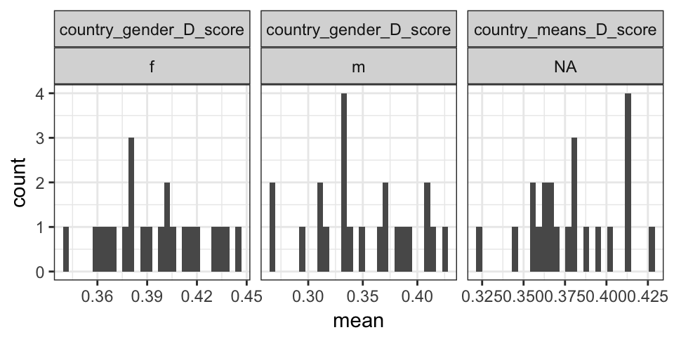

```r
ggplot(d, aes(x = mean)) +
  geom_histogram() +
  facet_wrap(~type + sex, scales = "free_x")+
  theme_bw()
```

### 1.1.2 Language

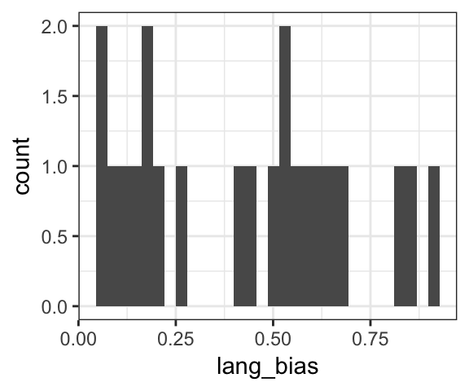

```r
ggplot(lang_bias, aes(x = lang_bias)) +
  geom_histogram() +
  theme_bw()
```

## 1.2 Correlation between measures

Each point below is a language. We find that male IAT bias is reliably correlated with bias from the embedding models.

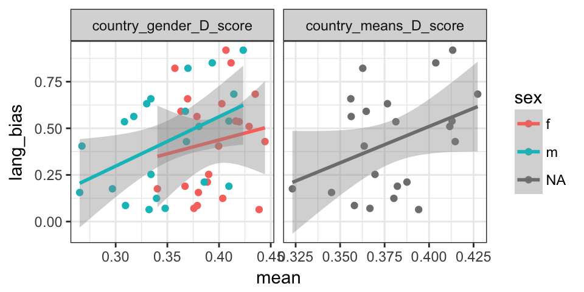

```r
d %>%
ggplot( aes(x = mean, y = lang_bias, group = sex, color = sex)) +
  geom_point() +
  geom_smooth(method = "lm") +
  facet_grid(.~ type, scales = "free_x", drop = T) +
  theme_bw()
```

```r
d %>%
  group_by(type, sex) %>%
  do(tidy(cor.test(.$mean, .$lang_bias))) %>%
  arrange(p.value) %>%
  select(-parameter, -method, -alternative) %>%
  kable()
```

| type | sex | estimate | statistic | p.value | conf.low | conf.high |
| --- | --- | --- | --- | --- | --- | --- |
| country_gender_D_score | m | 0.4477692 | 2.2395419 | 0.0366428 | 0.0322487 | 0.7313172 |
| country_means_D_score | NA | 0.3787269 | 1.8300407 | 0.0821900 | -0.0510297 | 0.6901379 |
| country_gender_D_score | f | 0.1534496 | 0.6944725 | 0.4953750 | -0.2867076 | 0.5401150 |

# 2 Explicit measures of bias

Next, we ask whether the explicit questions asked in the IAT correlate with the language IAT measure.

We look at two measures (explained here: https://mfr.osf.io/render?url=https://osf.io/thvzf/?action=download%26mode=render):

assocareer: ’How strongly do you associate the following with males and females? Career; 1=female 7= male

assofamily: ’How strongly do you associate the following with males and females? Family; 1=female 7= male

```r
# Read in behavior and language biases
countries_langs <- read_csv("../../data/other/countries_lang.csv") %>%
  mutate(language_name = ifelse(language_name == "Spanish; Castilian", "Spanish", language_name),
         language_name = ifelse(language_name == "Dutch; Flemish", "Dutch", language_name))


IAT_behavior_measures_exp <- read_csv("IAT_behavior_measures.csv") %>%
  left_join(countries_langs %>% select(country_name, language_name, language_code)) %>%
  filter(type %in% c("country_fam_male",
             "country_career_male")) %>%
  group_by(type, language_code, sex) %>%
  summarize(mean = mean(mean))

d <- left_join(IAT_behavior_measures_exp, lang_bias) %>%
  mutate_if(is.character, as.factor) %>%
  filter(!is.na(lang_bias))
```

## 2.1 Measure

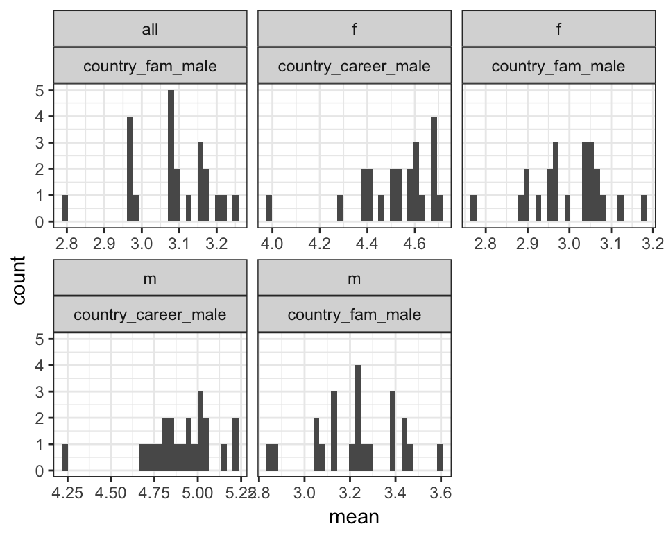

```r
ggplot(d, aes(x = mean)) +
  geom_histogram() +
  facet_wrap(sex ~type, scales = "free_x",)+
  theme_bw()
```

## 2.2 Correlation between measures

I find that the degree to which males associate family with males is negatively correlated with bias. The career question is not predictive.

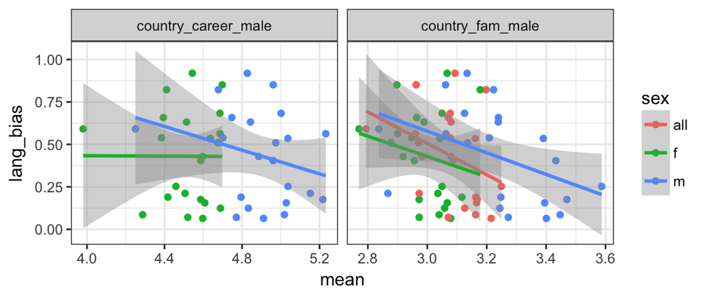

```r
d %>%
ggplot( aes(x = mean, y = lang_bias, group = sex, color = sex)) +
  geom_point() +
  geom_smooth(method = "lm") +
  facet_grid(.~ type, scales = "free_x", drop = T) +
  theme_bw()
```

```r
d %>%
  group_by(type, sex) %>%
  do(tidy(cor.test(.$mean, .$lang_bias))) %>%
  arrange(p.value) %>%
  select(-parameter, -method, -alternative) %>%
  kable()
```

| type | sex | estimate | statistic | p.value | conf.low | conf.high |
| --- | --- | --- | --- | --- | --- | --- |
| country_fam_male | m | -0.4425174 | -2.2068315 | 0.0391791 | -0.7282558 | -0.0257047 |
| country_fam_male | all | -0.3651060 | -1.7538813 | 0.0947633 | -0.6817686 | 0.0667824 |
| country_career_male | m | -0.2716986 | -1.2625678 | 0.2212680 | -0.6220509 | 0.1693037 |
| country_fam_male | f | -0.2011662 | -0.9184176 | 0.3693442 | -0.5740846 | 0.2408714 |
| country_career_male | f | -0.0035605 | -0.0159230 | 0.9874536 | -0.4245316 | 0.4186765 |

# 3 Relationship between grammar type and bias measures

Finally, we ask whether a language encodes gender predicts its bias. WALS strangely only has this coded for about half of the langauges in our sample. I coded the rest from wikipedia (https://en.wikipedia.org/wiki/List_of_languages_by_type_of_grammatical_genders). For the ones that were coded by both, they always agreed. Here are the distributions of languages across grammar types (CN = common/neuter, MF = masculine/feminine, MFN = masculine/feminine/neuter).

```r
gender_data <- read_csv("../language_bias/gender_grammar.csv") %>%
  rename(wikipedia_grammar_type = Wikipedia) %>%
  select(language_code, language_name, wikipedia_grammar_type) %>%
  filter(!is.na(wikipedia_grammar_type)) %>%
  mutate(wikipedia_grammar_type2 = ifelse(wikipedia_grammar_type == "none", "none", "MF"))
```

```r
kable(arrange(gender_data, wikipedia_grammar_type2))
```

| language_code | language_name | wikipedia_grammar_type | wikipedia_grammar_type2 |
| --- | --- | --- | --- |
| ar | arabic | MF | MF |
| nl | dutch; flemish | CN | MF |
| pt | portuguese | MF | MF |
| da | danish | CN | MF |
| it | italian | MF | MF |
| no | norwegian | CN | MF |
| pl | polish | MFN | MF |
| sv | swedish | MFN | MF |
| es | spanish; castilian | MF | MF |
| de | german | MFN | MF |
| ru | russian | MFN | MF |
| fr | french | MF | MF |
| el | greek | MFN | MF |
| he | hebrew | MF | MF |
| hr | croatian | MFN | MF |
| ro | romanian | MFN | MF |
| ja | japanese | none | none |
| ko | korean | none | none |
| ms | malay | none | none |
| fa | persian | none | none |
| zh | chinese | none | none |
| fi | finnish | none | none |
| id | indonesian | none | none |
| tr | turkish | none | none |
| en | english | none | none |
| tl | tagalog | none | none |
| th | thai | none | none |

```r
count(gender_data, wikipedia_grammar_type2)  %>%
  kable()
```

| wikipedia_grammar_type2 | n |
| --- | --- |
| MF | 16 |
| none | 11 |

```r
count(gender_data, wikipedia_grammar_type2)  %>%
  kable()
```

| wikipedia_grammar_type2 | n |
| --- | --- |
| MF | 16 |
| none | 11 |

## 3.1 Implicit measures

For both IAT measures, languages with bigger grammatical bias have large implicit bias than languages that don’t, and this effect is larger for male participants.

### 3.1.1 Behavioral IAT measure

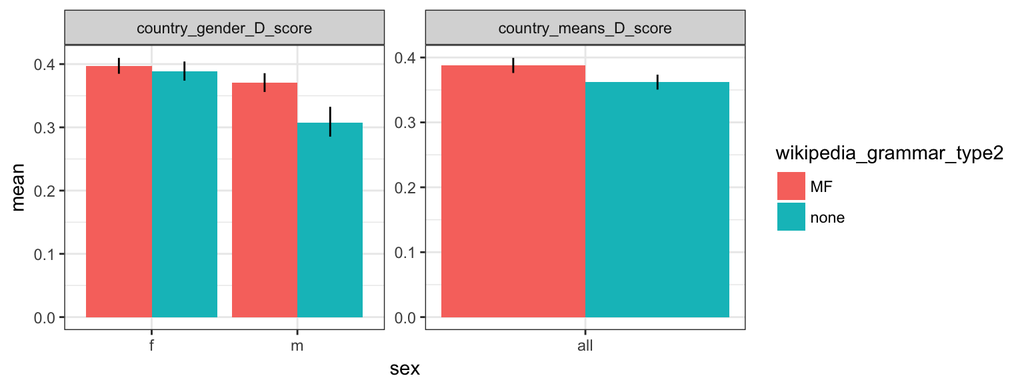

```r
full_d <- IAT_behavior_measures_imp %>%
  full_join(lang_bias, by = "language_code") %>%
  full_join(gender_data, by = "language_code") %>%
  select(-contains("test"))

iat_means <-  full_d %>%
  filter(!is.na(wikipedia_grammar_type2)) %>%
  mutate(sex = ifelse(is.na(sex), "all", sex)) %>%
  group_by(type, sex, wikipedia_grammar_type2) %>%
  multi_boot_standard(col = "mean", na.rm = T)

  ggplot(iat_means, aes(x = sex,
                                 y = mean, fill = wikipedia_grammar_type2)) +
  geom_bar(stat = "identity", position = "dodge") +
  facet_wrap(~type, scales = "free") +
  geom_linerange(aes(ymin = ci_lower, ymax = ci_upper),
                 position = position_dodge(width = .9)) +
  theme_bw()
```

### 3.1.2 Language IAT measures

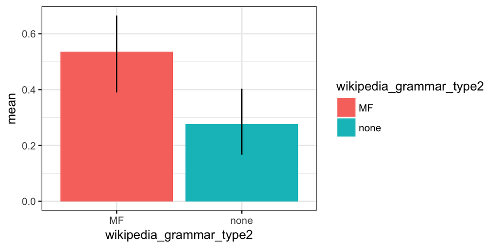

```r
lang_means <-  full_d %>%
  filter(!is.na(wikipedia_grammar_type2)) %>%
  mutate(sex = ifelse(is.na(sex), "all", sex)) %>%
  filter(sex == "all") %>%
  group_by(wikipedia_grammar_type2) %>%
  multi_boot_standard(col = "lang_bias", na.rm = T)

  ggplot(lang_means, aes(x = wikipedia_grammar_type2,
                                 y = mean, fill = wikipedia_grammar_type2)) +
  geom_bar(stat = "identity", position = "dodge") +
  geom_linerange(aes(ymin = ci_lower, ymax = ci_upper),
                 position = position_dodge(width = .9)) +
  theme_bw()
```

## 3.2 Explicit measure

This effect is also in the predicted direction: Languages that don’t have grammatical gender are more likely to associate males with family (but the reverse is true for career?).

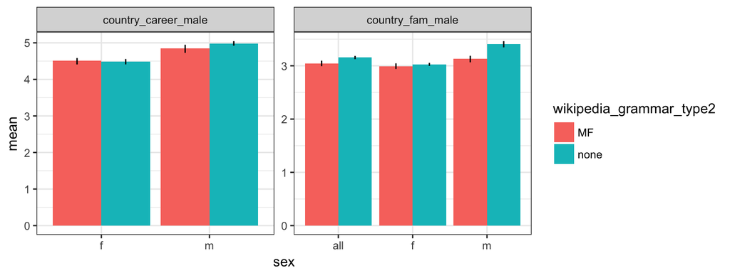

```r
full_d <- IAT_behavior_measures_exp %>%
  full_join(lang_bias, by = "language_code") %>%
  full_join(gender_data, by = "language_code") %>%
  select(-contains("test"))

iat_means <-  full_d %>%
  filter(!is.na(wikipedia_grammar_type2)) %>%
  mutate(sex = ifelse(is.na(sex), "all", sex)) %>%
  group_by(type, sex, wikipedia_grammar_type2) %>%
  multi_boot_standard(col = "mean", na.rm = T)

  ggplot(iat_means, aes(x = sex,
                                 y = mean, fill = wikipedia_grammar_type2)) +
  geom_bar(stat = "identity", position = "dodge") +
  facet_wrap(~type, scales = "free") +
  geom_linerange(aes(ymin = ci_lower, ymax = ci_upper),
                 position = position_dodge(width = .9)) +
  theme_bw()
```